# Exploratory Analysis

Team: Yuhaniz, Morgan, Dainese, and Karen

## Introduction

In our exploratory data analysis, we further investigated the racial inequalities and inequities around police violence in the United States by looking at the distribution of the average number of fatal shootings and the distribution of the race of victims by proportion. We also analyzed the relationship between age and race of victims in police shootings and the relationship between the average annual police homicide rate of Black people and White people to discover and highlight possible patterns or relationships of interest.

## Distribution of Variables

### Distribution of Fatal Shootings from 2015-2020

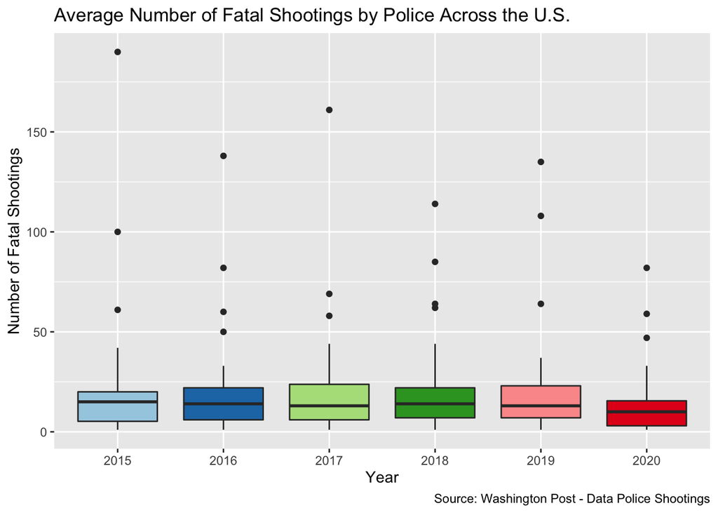

Over the years, the average number of fatal shootings by police offers has remained relatively consistent. What is most interesting about the way fatal shootings have been distributed across years is that the outlier amounts have changed drastically from year to year. Each point represents an individual state, which means that certain states do fluctuate a lot in their fatal shooting rate. It is also interesting to note that in 2020, there was a lower number of fatal shootings, despite the increased attention to police brutality and the Black Lives Matter movement. Part of this may be due to the fact that the pandemic impacted the number of shootings that occurred in general. This graph also represents the national average, and does not take into account inequality, which has been one of the primary issues in policy brutality.

### Distribution of Race of Victims of Police Shootings by Proportion (2013-2019)

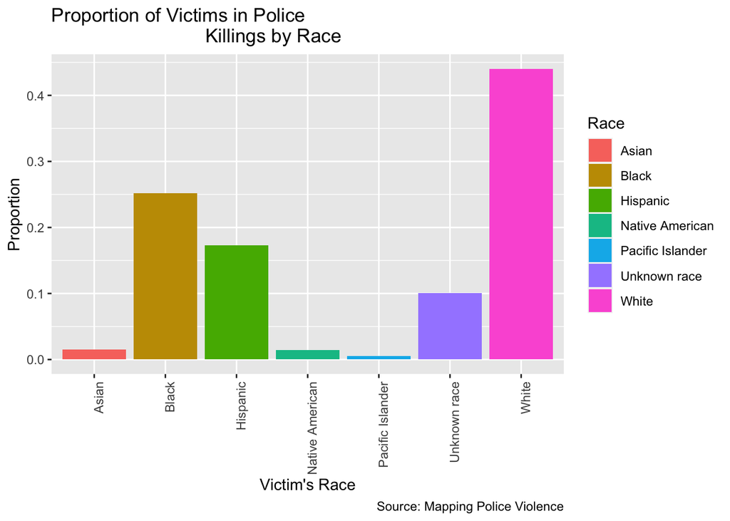

This graph shows the proportion of victims in police shootings by race. From the data given, we can see that the top 3 races of victims in police killings from 2013 to 2020 are White (44%), Black (25.2%) and Hispanic (17.2%). This could be due to a variety of reasons such as geographic location, demographic characteristics, and number of crimes committed by race. Lower proportions of victims for certain races such as Asians and Native Americans could be explained by small population numbers or cultural differences that lead to less police shootings.

## Relationship between Variables

### Relationship between Age and Race on Police Shootings

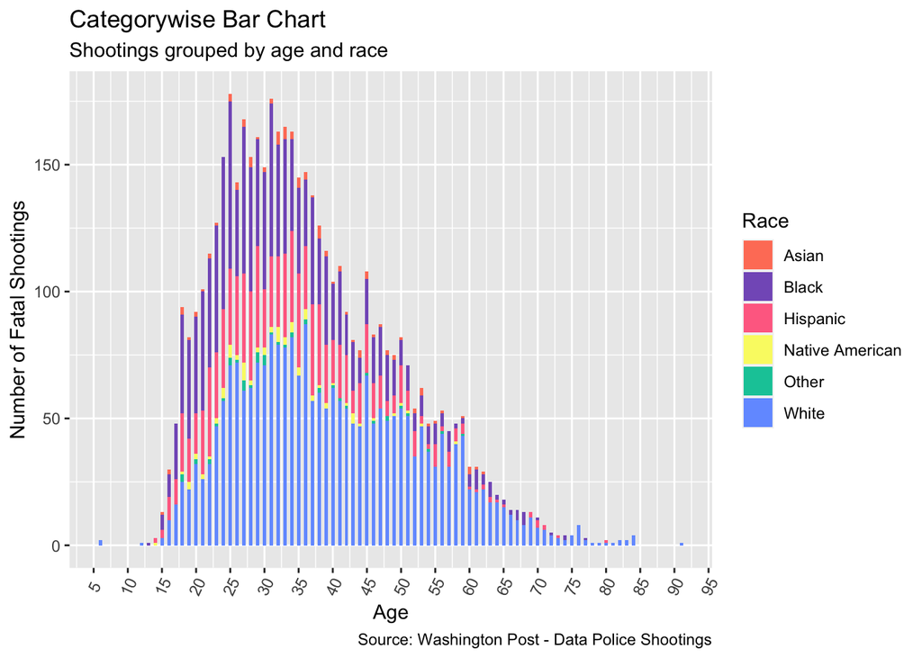

### Relationship between Average Annual Police Homicide Rates between Black and White People

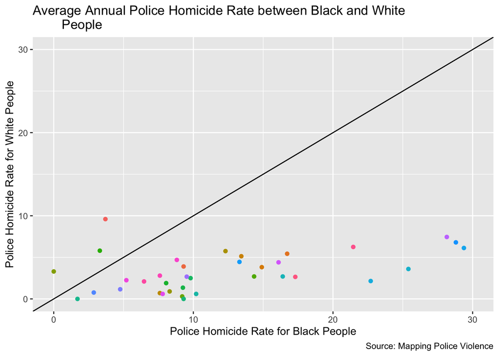

This scatter plot shows that the average annual police homicide rate between Black and White people are not proportional. All the points, or states, under the line means that the average annual police homicide rate is greater among Black people than White people. The points above the line means that police homicide rate is greater among White people than Black people. The graph shows that three states, Hawaii, Kansas, and Alabama, have higher rates of police homicide among White people than Black people. However, the majority of states have much more incidents of higher rates of police homicide for Black people, as well as a rate of a higher degree.